# R Notebook

```r
library(readr)
library(ggplot2)
library(dplyr)
library(corrplot)
library(caret)
library(forecast)
library(randomForest)
```

## Introduccion

Este notebook se centra en explorar y analizar un conjunto de datos de un supermercado, con el objetivo principal de predecir el total de ventas durante los días del mes de marzo.

## Objetivos

El propósito fundamental de este notebook es desarrollar un modelo predictivo capaz de estimar con precisión el total de ventas diarias en el mes de marzo. Para alcanzar este objetivo, se llevará a cabo una exploración detallada de los datos, se analizarán las tendencias de compra en diferentes líneas de productos y se aplicarán técnicas de series temporales, como ARIMA, para modelar y prever el comportamiento de las ventas. Además, se incorporará el enfoque de Random Forest para evaluar su capacidad predictiva y comparar los resultados con los obtenidos a través de series temporales.

Cargar dataset

```r
sales <- read_csv('supermarket_db.csv', show_col_types = FALSE)
#head(df)
summary(sales)
```

```
##   Invoice ID           Branch              City           Customer type
##  Length:1000        Length:1000        Length:1000        Length:1000
##  Class :character   Class :character   Class :character   Class :character
##  Mode  :character   Mode  :character   Mode  :character   Mode  :character
##
##
##
##     Gender          Product line         Unit price       Quantity
##  Length:1000        Length:1000        Min.   :10.08   Min.   : 1.00
##  Class :character   Class :character   1st Qu.:32.88   1st Qu.: 3.00
##  Mode  :character   Mode  :character   Median :55.23   Median : 5.00
##                                        Mean   :55.67   Mean   : 5.51
##                                        3rd Qu.:77.94   3rd Qu.: 8.00
##                                        Max.   :99.96   Max.   :10.00
##      Tax 5%            Total             Date               Time
##  Min.   : 0.5085   Min.   :  10.68   Length:1000        Length:1000
##  1st Qu.: 5.9249   1st Qu.: 124.42   Class :character   Class1:hms
##  Median :12.0880   Median : 253.85   Mode  :character   Class2:difftime
##  Mean   :15.3794   Mean   : 322.97                      Mode  :numeric
##  3rd Qu.:22.4453   3rd Qu.: 471.35
##  Max.   :49.6500   Max.   :1042.65
##    Payment               cogs        gross margin percentage  gross income
##  Length:1000        Min.   : 10.17   Min.   :4.762           Min.   : 0.5085
##  Class :character   1st Qu.:118.50   1st Qu.:4.762           1st Qu.: 5.9249
##  Mode  :character   Median :241.76   Median :4.762           Median :12.0880
##                     Mean   :307.59   Mean   :4.762           Mean   :15.3794
##                     3rd Qu.:448.90   3rd Qu.:4.762           3rd Qu.:22.4453
##                     Max.   :993.00   Max.   :4.762           Max.   :49.6500
##      Rating
##  Min.   : 4.000
##  1st Qu.: 5.500
##  Median : 7.000
##  Mean   : 6.973
##  3rd Qu.: 8.500
##  Max.   :10.000
```

Exploración de los datos

```r
media_total <- mean(sales$Total)
cat("El monto total por transacción es", media_total)
```

```
## El monto total por transacción es 322.9667
```

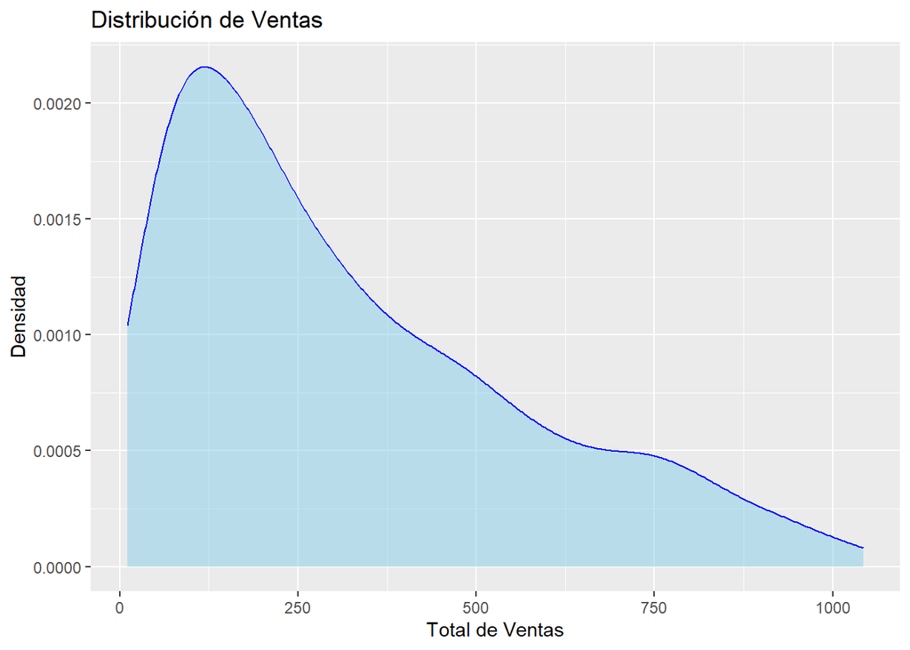

```r
ggplot(sales, aes(x = Total)) +
  geom_density(fill = "skyblue", color = "blue", alpha = 0.5) +
  labs(title = "Distribución de Ventas",
       x = "Total de Ventas",
       y = "Densidad")
```

Cuál sucursal ingresa más?

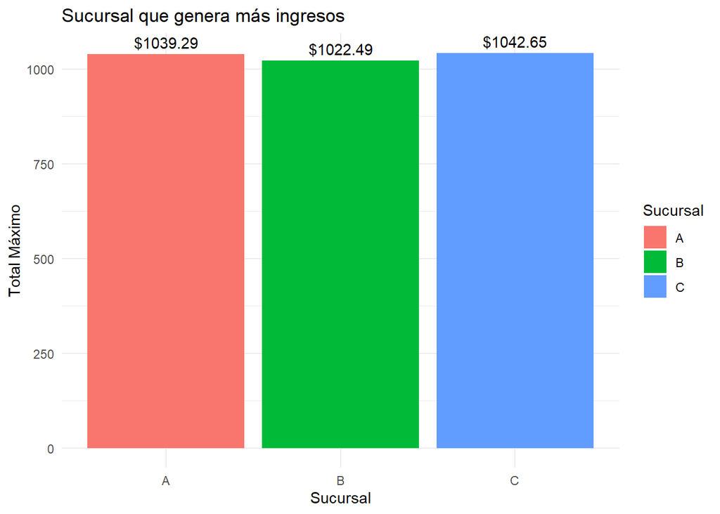

```r
branch_summary <- sales %>%
  group_by(Branch) %>%
  summarise(Max_Total = max(Total), Transaction_Count = n())

# Crear un gráfico de barras
ggplot(branch_summary, aes(x = Branch, y = Max_Total, fill = Branch)) +
  geom_bar(stat = "identity", position = "dodge") +
  geom_text(aes(label = sprintf("$%.2f", Max_Total)), vjust = -0.5, position = position_dodge(width = 1)) +
  labs(title = "Sucursal que genera más ingresos",
       x = "Sucursal",
       y = "Total Máximo",
       fill = "Sucursal") +
  theme_minimal()
```

Satisfacción de clientes.

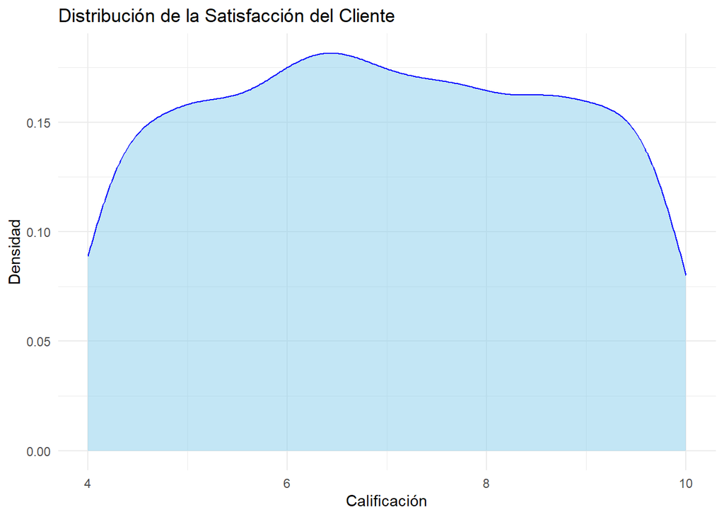

```r
ggplot(sales, aes(x = Rating)) +
  geom_density(fill = "skyblue", color = "blue", alpha = 0.5) +
  labs(title = "Distribución de la Satisfacción del Cliente",
       x = "Calificación",
       y = "Densidad") +
  theme_minimal()
```

Linea de producto más popular en Enero.

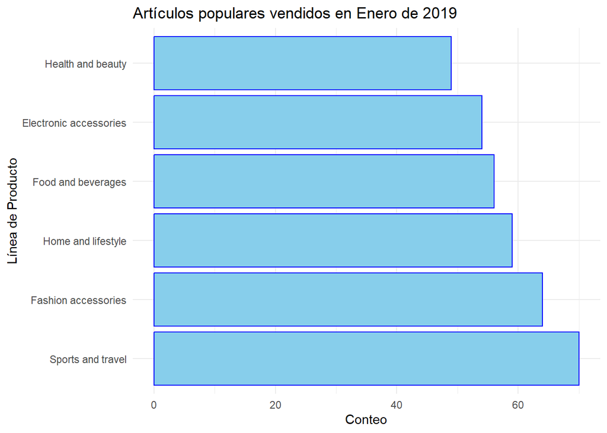

```r
sales$Date <- as.Date(sales$Date, format = "%m/%d/%Y")

# Filtrar por enero
sales_january <- sales[sales$Date >= as.Date("2019-01-01") & sales$Date <= as.Date("2019-01-31"), ]

product_counts <- sales_january %>%
  group_by(`Product line`) %>%
  summarise(Count = n())

# Ordenar el dataframe por la frecuencia en orden descendente
product_counts <- product_counts[order(-product_counts$Count), ]

# Crear un gráfico de barras horizontales
ggplot(product_counts, aes(x = Count, y = reorder(`Product line`, -Count))) +
  geom_bar(stat = "identity", fill = "skyblue", color = "blue") +
  labs(title = "Artículos populares vendidos en Enero de 2019",
       x = "Conteo",
       y = "Línea de Producto") +
  theme_minimal()
```

Linea de producto más popular en Febrero.

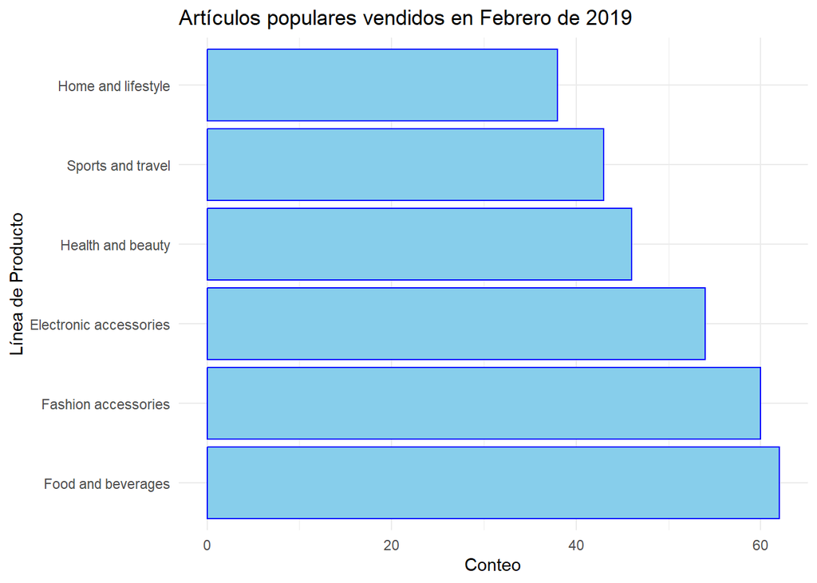

```r
# Filtrar por febrero
sales_february <- sales[sales$Date >= as.Date("2019-02-01") & sales$Date <= as.Date("2019-02-28"), ]

product_counts_february <- sales_february %>%
  group_by(`Product line`) %>%
  summarise(Count = n())

product_counts_february <- product_counts_february[order(-product_counts_february$Count), ]

# Crear un gráfico de barras horizontales
ggplot(product_counts_february, aes(x = Count, y = reorder(`Product line`, -Count))) +
  geom_bar(stat = "identity", fill = "skyblue", color = "blue") +
  labs(title = "Artículos populares vendidos en Febrero de 2019",
       x = "Conteo",
       y = "Línea de Producto") +
  theme_minimal()
```

Linea de producto más popular en Marzo.

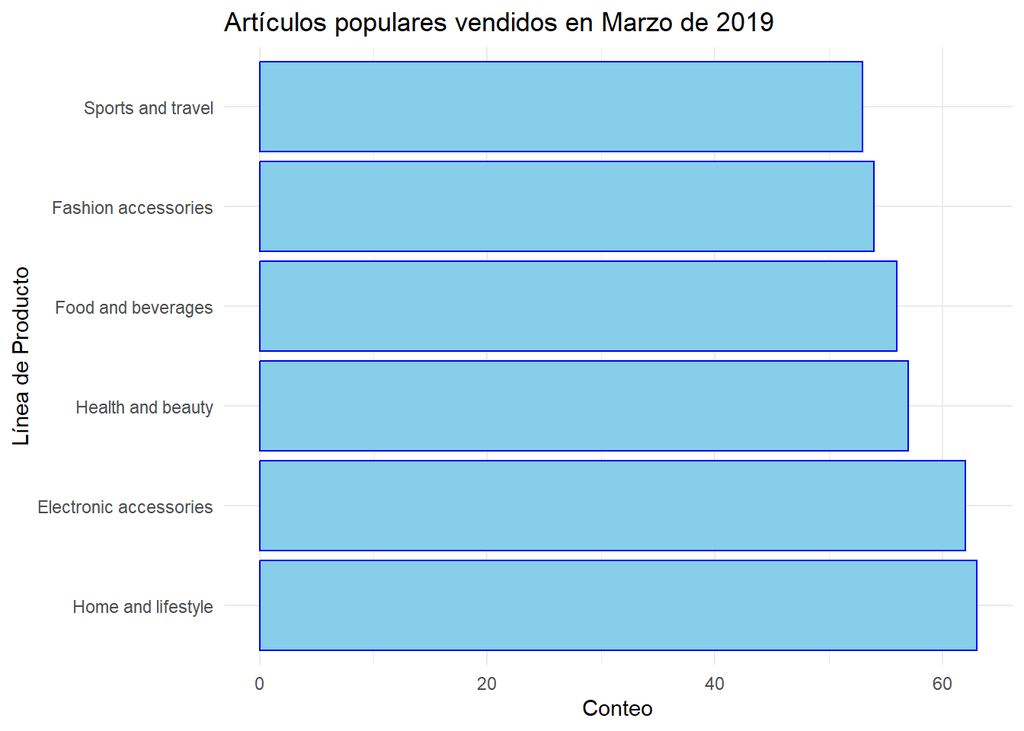

```r
# Filtrar por febrero
sales_march <- sales[sales$Date >= as.Date("2019-03-01") & sales$Date <= as.Date("2019-03-31"), ]

product_counts_march <- sales_march %>%
  group_by(`Product line`) %>%
  summarise(Count = n())

product_counts_march <- product_counts_march[order(-product_counts_march$Count), ]

# Crear un gráfico de barras horizontales
ggplot(product_counts_march, aes(x = Count, y = reorder(`Product line`, -Count))) +
  geom_bar(stat = "identity", fill = "skyblue", color = "blue") +
  labs(title = "Artículos populares vendidos en Marzo de 2019",
       x = "Conteo",
       y = "Línea de Producto") +
  theme_minimal()
```

Gráfico de densidad del total de ventas hechas en Enero

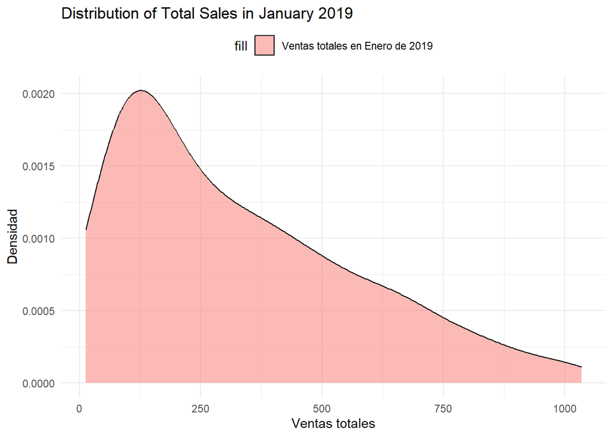

```r
ggplot(sales_january, aes(x = Total, fill = "Ventas totales en Enero de 2019")) +
  geom_density(alpha = 0.5) +
  labs(title = "Distribution of Total Sales in January 2019",
       x = "Ventas totales",
       y = "Densidad") +
  theme_minimal() +
  theme(legend.position = "top")
```

El resultado del análisis de densidad nos muestra que los datos están sesgados hacia los valores entre 0 y 260 en su mayoría, por lo que hay más probabilidad de que las personas realicen compras totales en ese rango de precio.

Vamos a analizar la variable Total con respecto a la variable Date mediante un análisis de series temporales.

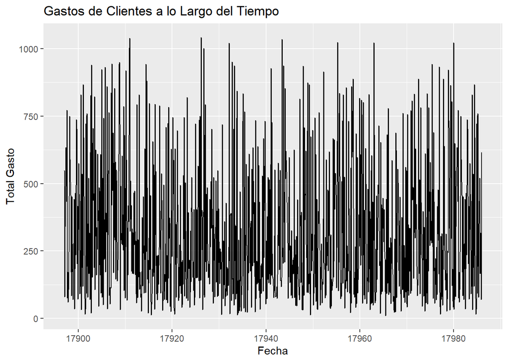

```r
sales$Date <- as.Date(sales$Date, format = "%m/%d/%Y")
time_series_data <- ts(sales$Total, start = c(min(sales$Date), 1), end = c(max(sales$Date), 12), frequency = 12)
autoplot(time_series_data, main = "Gastos de Clientes a lo Largo del Tiempo", xlab = "Fecha", ylab = "Total Gasto")
```

Descomponer la serie temporal: En el paso de descomposición de la serie temporal, se utiliza la función decompose() para separar la serie temporal en tres componentes principales: tendencia (trend), estacionalidad (seasonal), y residuos (remainder o random). Estos componentes proporcionan información sobre cómo la serie temporal cambia a lo largo del tiempo y ayudan a entender patrones subyacentes.

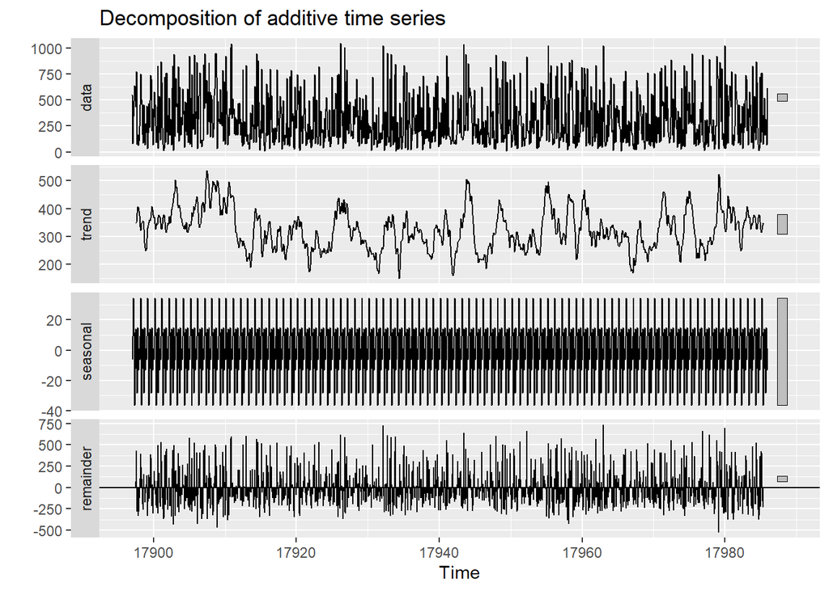

```r
#Descomponer la serie temporal
decomposed <- decompose(time_series_data)
autoplot(decomposed)
```

Predeciremos las ventas en el mes de marzo.

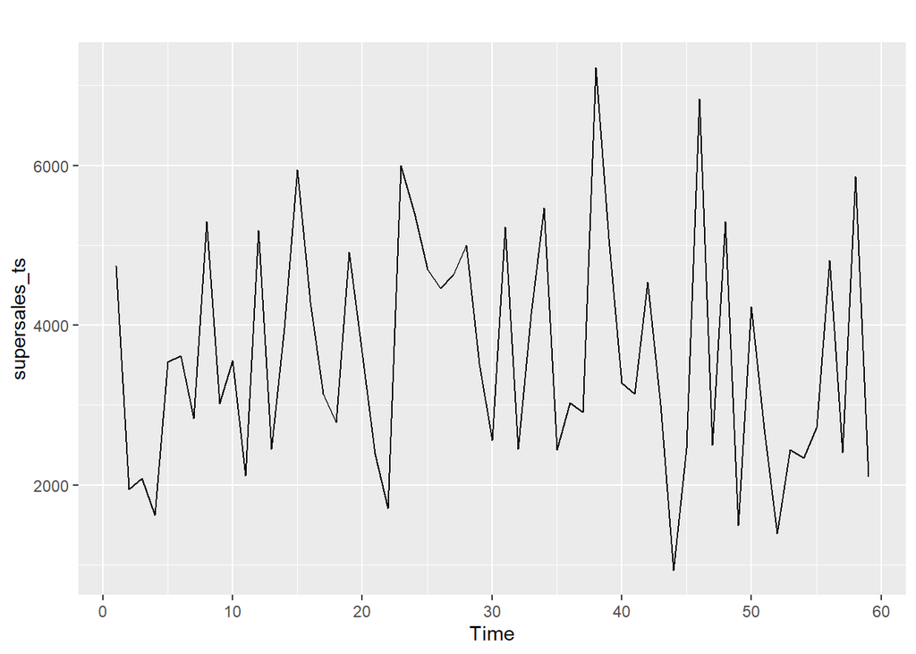

```r
sales$Date <- as.Date(sales$Date, format="%m/%d/%Y")
sales$Dia <- as.Date(sales$Date)
nuevo_df <- sales %>%
  group_by(Dia) %>%
  summarise(Ventas_diarias = sum(Total))

supersales_ts = ts(nuevo_df$Ventas_diarias, start = c(1), end = c(59), frequency = 1)
modelo <- auto.arima(supersales_ts)
autoplot(supersales_ts)
```

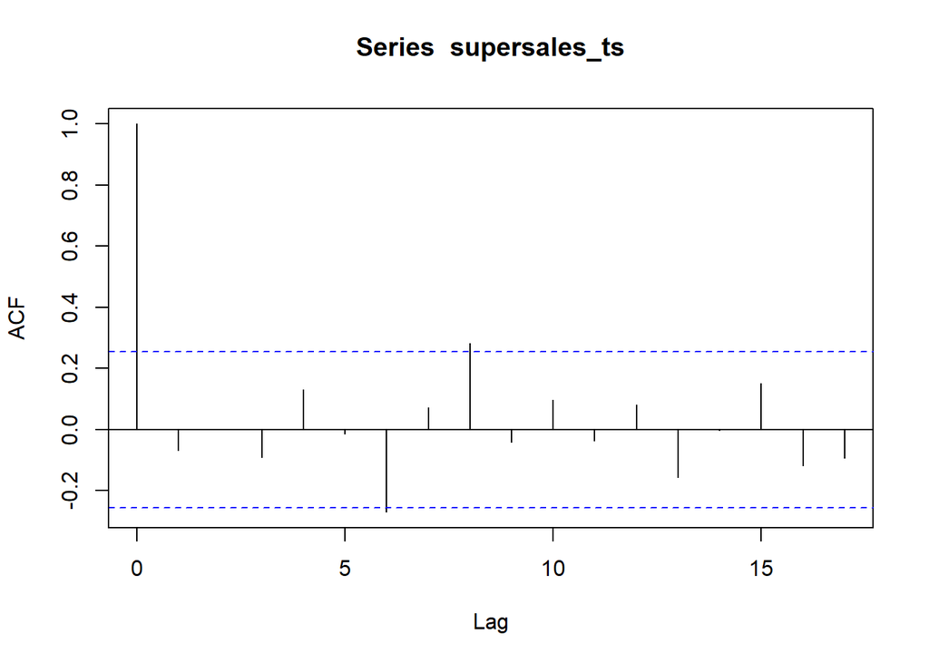

```r
acf(supersales_ts)
```

En la gráfica de correlación podemos ver que no existe una correlación muy destacada entre los lags, esto indica que no hay mucha correlación entre los datos actuales y los datos anteriores en la serie temporal. Como las ventas diarias son bastante aleatorias y no muestran un patrón o tendencia clara. A pesar de esto utilizaremos modelos como ARIMA para prever futuros resultados y analizar las predicciones con los datos reales.

```r
avg_model = Arima(supersales_ts, c(0,0,0)) # autocorrelacion 0 | integracion 0 | meanaf 0
avg_forecast = forecast(avg_model)
str(avg_forecast)
```

```
## List of 10
##  $ method   : chr "ARIMA(0,0,0) with non-zero mean"
##  $ model    :List of 18
##   ..$ coef     : Named num 3619
##   .. ..- attr(*, "names")= chr "intercept"
##   ..$ sigma2   : num 2123207
##   ..$ var.coef : num [1, 1] 35377
##   .. ..- attr(*, "dimnames")=List of 2
##   .. .. ..$ : chr "intercept"
##   .. .. ..$ : chr "intercept"
##   ..$ mask     : logi TRUE
##   ..$ loglik   : num -513
##   ..$ aic      : num 1030
##   ..$ arma     : int [1:7] 0 0 0 0 1 0 0
##   ..$ residuals: Time-Series [1:59] from 1 to 59: 1126.3 -1673.3 -1540.7 -1995.1 -82.2 ...
##   ..$ call     : language Arima(y = supersales_ts, order = c(0, 0, 0))
##   ..$ series   : chr "supersales_ts"
##   ..$ code     : int 0
##   ..$ n.cond   : int 0
##   ..$ nobs     : int 59
##   ..$ model    :List of 10
##   .. ..$ phi  : num(0)
##   .. ..$ theta: num(0)
##   .. ..$ Delta: num(0)
##   .. ..$ Z    : num 1
##   .. ..$ a    : num -1522
##   .. ..$ P    : num [1, 1] 0
##   .. ..$ T    : num [1, 1] 0
##   .. ..$ V    : num [1, 1] 1
##   .. ..$ h    : num 0
##   .. ..$ Pn   : num [1, 1] 1
##   ..$ aicc     : num 1030
##   ..$ bic      : num 1034
##   ..$ x        : Time-Series [1:59] from 1 to 59: 4745 1946 2078 1624 3537 ...
##   ..$ fitted   : Time-Series [1:59] from 1 to 59: 3619 3619 3619 3619 3619 ...
##   ..- attr(*, "class")= chr [1:3] "forecast_ARIMA" "ARIMA" "Arima"
##  $ level    : num [1:2] 80 95
##  $ mean     : Time-Series [1:10] from 60 to 69: 3619 3619 3619 3619 3619 ...
##  $ lower    : Time-Series [1:10, 1:2] from 60 to 69: 1751 1751 1751 1751 1751 ...
##   ..- attr(*, "dimnames")=List of 2
##   .. ..$ : NULL
##   .. ..$ : chr [1:2] "80%" "95%"
##  $ upper    : Time-Series [1:10, 1:2] from 60 to 69: 5486 5486 5486 5486 5486 ...
##   ..- attr(*, "dimnames")=List of 2
##   .. ..$ : NULL
##   .. ..$ : chr [1:2] "80%" "95%"
##  $ x        : Time-Series [1:59] from 1 to 59: 4745 1946 2078 1624 3537 ...
##  $ series   : chr "supersales_ts"
##  $ fitted   : Time-Series [1:59] from 1 to 59: 3619 3619 3619 3619 3619 ...
##  $ residuals: Time-Series [1:59] from 1 to 59: 1126.3 -1673.3 -1540.7 -1995.1 -82.2 ...
##  - attr(*, "class")= chr "forecast"
```

```r
avg_forecast = forecast(avg_model, 30)
avg_forecast$mean
```

```
## Time Series:
## Start = 60
## End = 89
## Frequency = 1
##  [1] 3618.835 3618.835 3618.835 3618.835 3618.835 3618.835 3618.835 3618.835
##  [9] 3618.835 3618.835 3618.835 3618.835 3618.835 3618.835 3618.835 3618.835
## [17] 3618.835 3618.835 3618.835 3618.835 3618.835 3618.835 3618.835 3618.835
## [25] 3618.835 3618.835 3618.835 3618.835 3618.835 3618.835
```

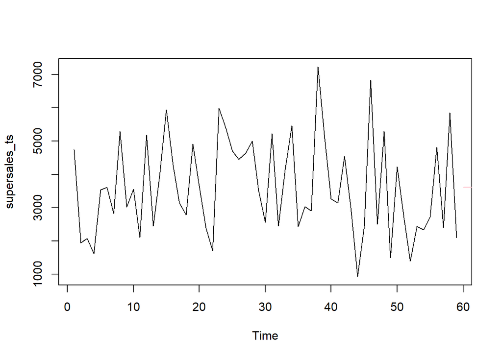

```r
plot(supersales_ts)
lines(avg_forecast$mean, col="pink")
```

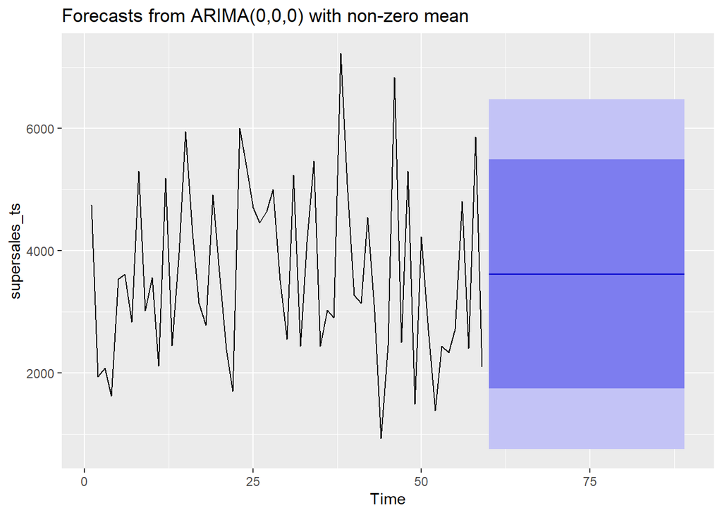

```r
autoplot(avg_forecast)
```

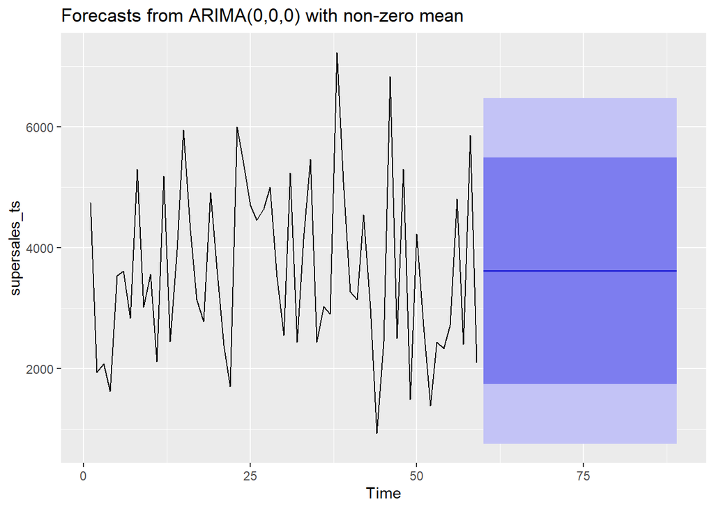

```r
arima_model = auto.arima(supersales_ts, seasonal = FALSE)
arima_forecast = forecast(arima_model, 30)
autoplot(arima_forecast)
```

```r
print(supersales_ts)
```

```
## Time Series:
## Start = 1
## End = 59
## Frequency = 1
##  [1] 4745.1810 1945.5030 2078.1285 1623.6885 3536.6835 3614.2050 2834.2440
##  [8] 5293.7325 3021.3435 3560.9490 2114.9625 5184.7635 2451.2040 3966.6165
## [15] 5944.2600 4289.0820 3142.7550 2780.4735 4914.7245 3655.4490 2392.0995
## [22] 1704.7695 5994.1875 5402.0505 4700.3670 4457.5125 4635.8970 4999.7115
## [29] 3516.5655 2558.2620 5232.4965 2444.5365 4140.9480 5467.9275 2439.4965
## [36] 3031.1295 2905.4235 7228.2105 5084.6565 3271.8945 3141.0225 4542.1530
## [43] 2998.9890  934.2375 2454.0915 6830.7855 2503.7670 5299.5705 1496.0295
## [50] 4228.1190 2706.4170 1393.7385 2442.3105 2339.5890 2722.4610 4807.2360
## [57] 2408.1645 5859.4515 2097.0180
```

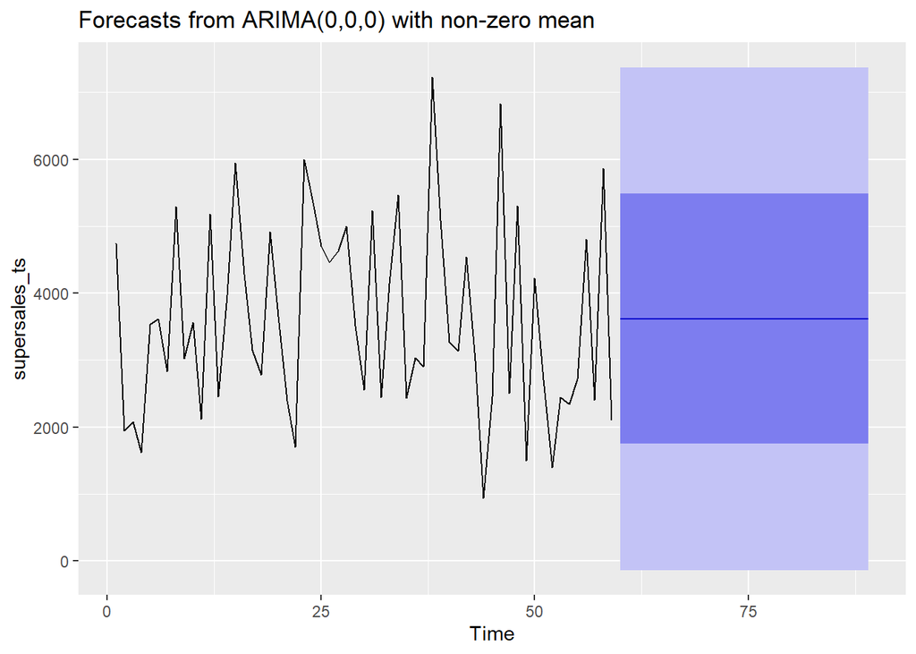

```r
seasonal_arima_model = auto.arima(supersales_ts)
season_arima_forecast = forecast(seasonal_arima_model, h = 30, level = c(80,99))
print(autoplot(season_arima_forecast))
```

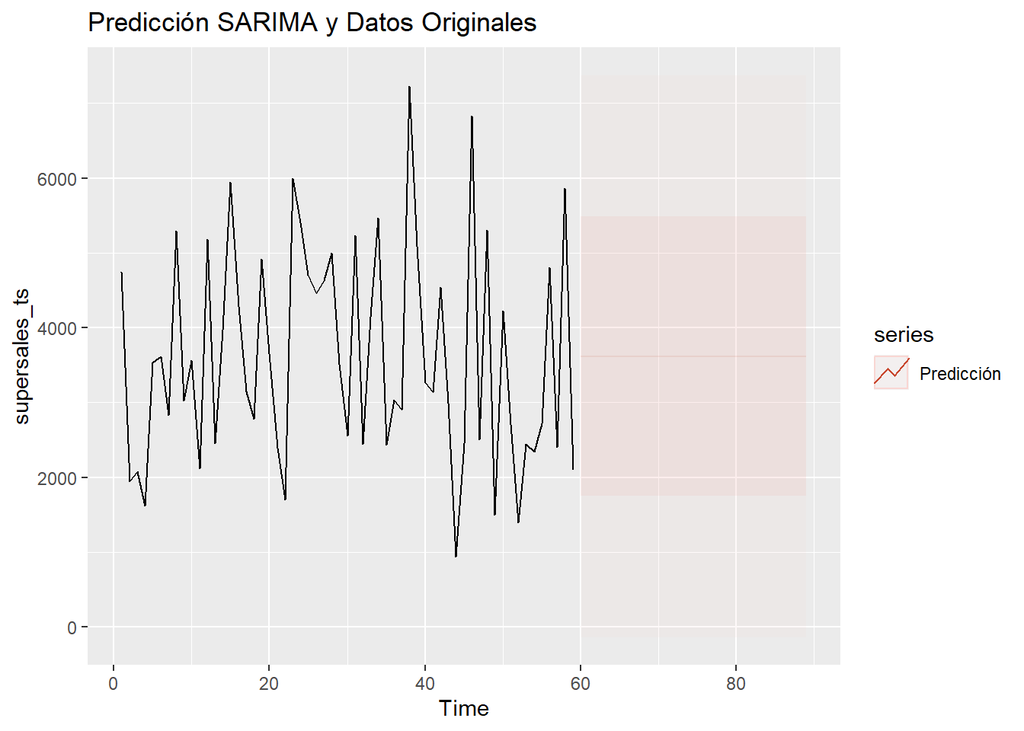

```r
autoplot(supersales_ts) +
  autolayer(season_arima_forecast, series = "Predicción", alpha = 0.1) +
  ggtitle("Predicción SARIMA y Datos Originales")
```

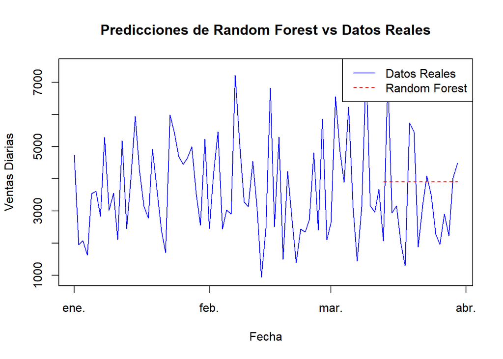

```r
set.seed(123)
train_data <- data.frame(
  Fecha = nuevo_df$Dia,
  Ventas_diarias = nuevo_df$Ventas_diarias
)

train_size <- floor(0.8 * nrow(train_data))
train_set <- train_data[1:train_size, ]
test_set <- train_data[(train_size + 1):nrow(train_data), ]

rf_model <- randomForest(Ventas_diarias ~ Fecha, data = train_set)

rf_predictions <- predict(rf_model, newdata = test_set)

rf_forecast <- data.frame(
  Fecha = test_set$Fecha,
  Ventas_diarias = rf_predictions
)

plot(nuevo_df$Dia, nuevo_df$Ventas_diarias, type = "l", col = "blue", lty = 1, xlab = "Fecha", ylab = "Ventas Diarias", main = "Predicciones de Random Forest vs Datos Reales")
lines(rf_forecast$Fecha, rf_forecast$Ventas_diarias, col = "red", lty = 2)
legend("topright", legend = c("Datos Reales", "Random Forest"), col = c("blue", "red"), lty = 1:2)
```

## Conclusiones La evaluación de nuestro modelo de series temporales revela que no logra captar la autocorrelación en los datos, lo que resulta en predicciones no válidas. Este desafío puede atribuirse a la limitada cantidad de muestras disponibles en nuestro conjunto de datos. Con una cantidad insuficiente de datos, la capacidad del modelo para identificar patrones y tendencias se ve comprometida, lo que afecta negativamente la calidad de las predicciones. En particular, el análisis de la función de autocorrelación (AFC) subraya la ausencia de una correlación significativa entre las observaciones históricas. Para mejorar la precisión de nuestras predicciones en futuros análisis de series temporales, se recomienda la adquisición de una cantidad más sustancial de datos para permitir una identificación más robusta de patrones subyacentes.